# Poll_report

Chien-Che Hung

10/7/2020

- To access the R Markdown report file please check this GitHub Repo link: [Report GitHub Repo](https://github.com/frankkhung/election_simulation/blob/main/election_result.Rmd)
- To access the code that simulate the data please check this GitHub Repo link: [Simulation GitHub Repo](https://github.com/frankkhung/election_simulation/blob/main/A2_report.Rmd)

Before running the simulation file, please download files in the following github repo links: - [Education Data GitHub Repo](https://github.com/frankkhung/election_simulation/blob/main/98-402-X2016010-11.csv) - [Age Distribution Data GitHub Repo](https://github.com/frankkhung/election_simulation/blob/main/10952320201004121154.xlsx)

Before running the R Markdown report file, please download the following simulated election data. - [Election Data](https://github.com/frankkhung/election_simulation/blob/main/election_data.xlsx)

# Non-Technical Executive Summary

Petit Poll has been hired by the Liberal Party to conduct the 2020 October Monthly Polling updates on approval rating and public opinions of the current government. Future federal elections could reference the results of this survey and analysis. In our survey methodology, each province has been assigned a sample number according to its ratio to Canada’s population. The samples would be interviewed by phone. Due to the COVID-19 pandemic situation right now, the ideology they had during the 2019 Federal Election would ultimately be different. Thus, it is essential to understand people’s thoughts under the current situation. After simulating the data, we found that people are generally satisfied with how the government responded to the COVID-19 situation. However, this pandemic also creates issues that people are starting to notice: the economy and health care. In general, people are satisfied with the government leads by the Liberal Party and Prime Minister Justin Trudeau, in which 36.8% of the respondents are willing to vote for him if the election is held today. Despite these simulated results positively showing the government’s performance, our survey under-sampled people who support Bloc Quebecois in Quebec, which leads to the Liberal Party having a higher rating in Quebec. Since this survey identified the satisfaction and the issues that Canada faces, we should dive into the issue and see how the government can help. With the government’s action, we can conduct the survey and see people’s reactions to the actions. From modifying the policies and surveying continuously, the party can quickly know how to move forward with Canada.

# Introduction

This report is a simulated monthly polling update conducted by Petit Poll for the Liberal Party of Canada during the COVID-19 Pandemic in 2020. Generally, the Liberal Party of Canada, led by Justin Trudeau, has a 5.9% lead compared to the Conservative Party led by Erin O’Toole. With the effects of COVID-19, job markets and health care systems start to play a significant role in Canada’s issue. This report will discuss the survey methodology implemented and the results that we obtained after analyzing the survey in detail.

# Survey Methodology

In this section, we will talk about the survey methodology used in our polling procedure. Since it is polling regarding the Federal Election, the **population** would be all the Canadian Citizens eligible to vote (people who are older and including 18 could vote in Canada). The **sampling frame** would be the telephone directory. According to Canadian Ratio-Television and Telecommunications Commission, 99.3% of the household had subscribed to either Landline phone service or Mobile Service (Government of Canada, 2019). Thus, with the area code’s help in different provinces, for instance, the Ontario area code is 647, 437, 249, etc. (Canada Area Code) and random digit dialing, we can successfully conduct Stratified Sampling and Simple Random Sample Without Replacement in each stratum. Since the proportion among the provinces is different, we used *the proportional allocation* method to decide how many samples we should obtain in each province, which sets the stratum sample size $n_h$ proportional to the stratum population size $N_h$. The formula is the following $n_h = \frac{n}{N}N_h = nW_h$.

However, since we need to create an unbiased survey and conduct a phone interview for our samples, this method’s cost is exceptionally time-consuming and labor-intensive. Before actually collecting the data, we need to randomly generate the phone numbers and make sure that the numbers work. Despite the time-consuming factor in the process, we believe that using random phone dialing would be a better option than Internet Surveys. It is comparatively easy to be biased for internet surveys since different provinces could have different political stances, which we cannot distinguish through internet surveys.

Since we are randomly generating the phone numbers, if there is a non-response sample, we would generate another phone number to survey. This will only be limited to non-response situations if the person conducting the survey decides not to record the response. Also, there would not be any privacy concerns in this situation because the survey does not ask samples’ regarding their personal information.

# Results

This report is a simulated monthly polling update conducted by Petit Poll for the Liberal Party of Canada during the COVID-19 Pandemic in 2020. Generally, the Liberal Party of Canada, led by Justin Trudeau, has a 5.9% lead compared to the Conservative Party led by Erin O’Toole. With the effects of COVID-19, job markets and health care systems start to play a significant role in Canada’s issue. This report will discuss the survey methodology implemented and the results that we obtained after analyzing the survey in detail.

## Question: How is your satisfaction with the current Canadian government? (Figure 1)

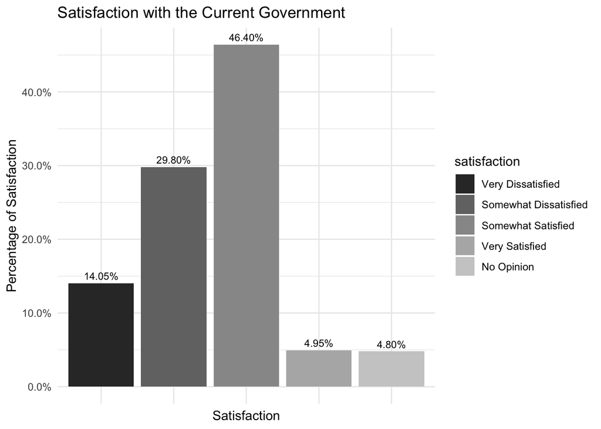

## Question: How much do you value the alignment between you and the candidate’s policies? (Figure 2)

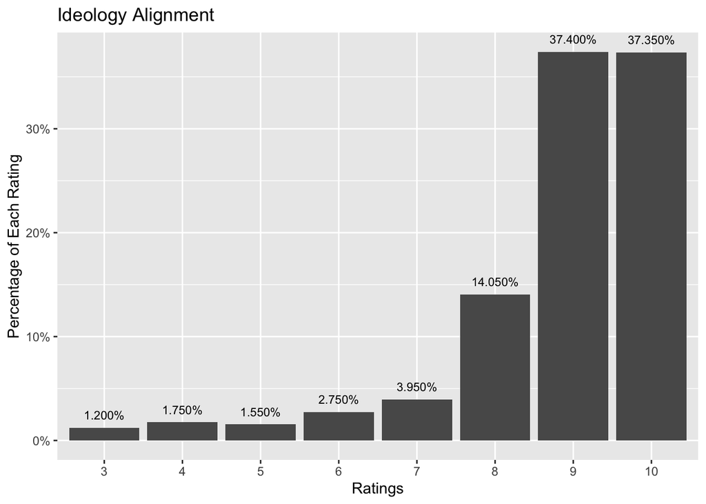

## Question: How would you rate the current government’s response on combating COVID-19? (Figure 3)

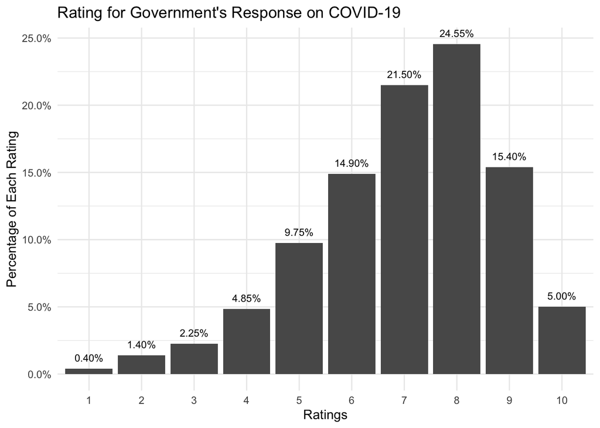

As this survey is conducted during the COVID-19 pandemic, we want to know how Canadian citizens think about the government’s performance. Generally, without considering each province, from rating 1 to 10, the mean is 7.029. However, since we conducted Stratified Random Sampling Without Replacement, we can apply the weight in each stratum to estimate the overall population mean, with the following formula: $\bar{y}{st} = \sum^H_{h = 1}W_h\bar{y}_h$. The result would be an unbiased estimator for the population mean. For the variance, we can obtain it by $v(\bar{y}_{st}) = \sum^H_{h = 1}W_h^2(1-\frac{n_h}{N_h})\frac{s^2_{yh}}{n_h}$. With this information, we can get an inference of the population. The population’s average rating is 7.0382, with a standard deviation of 0.00157 (Table 1).

Population Inference from Stratified Sample

[output not shown]

## Question: In your opinion, what is the most important issue facing in Canada today? (Figure 4)

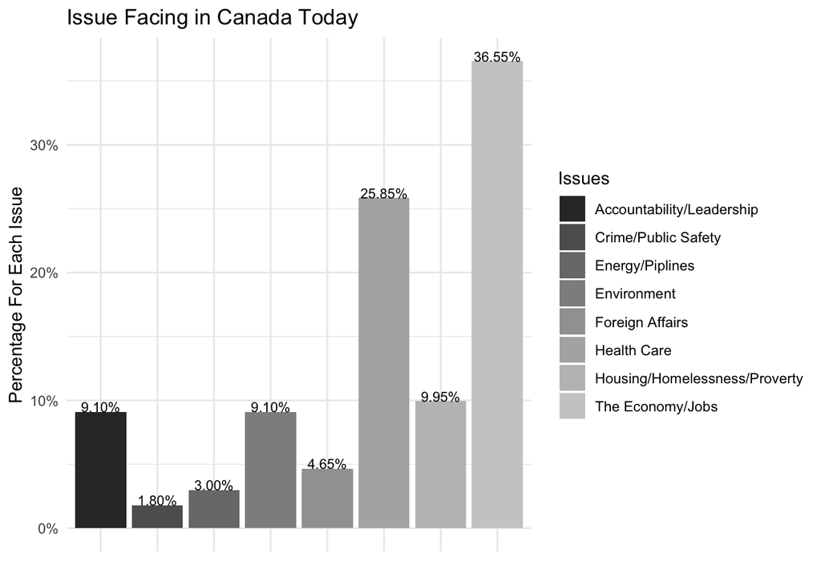

## Question: If the Federal Election were being held today, who would you vote for? (Table 2)

Voting Intentions (In Percentages)

|  | 18-24 | 25-34 | 35-44 | 45_54 | 55-64 | 65+ | Ontario | British Columbia | Alberta | Quebec | Other | Total |
| --- | --- | --- | --- | --- | --- | --- | --- | --- | --- | --- | --- | --- |
| Justin Trudeau/Liberal | 35.91 | 40.85 | 36.53 | 32.96 | 37.54 | 36.97 | 34.66 | 37.65 | 41.95 | 37.23 | 36.96 | 36.8 |
| Erin O’Toole/Conservative | 28.64 | 30.18 | 31.89 | 30.73 | 30.66 | 32.23 | 31.84 | 32.79 | 29.66 | 27.92 | 32.25 | 30.9 |
| Jagmeet Singh/New Democratic | 18.64 | 15.55 | 17.96 | 20.11 | 18.05 | 14.93 | 17.07 | 16.60 | 14.83 | 20.35 | 16.30 | 17.4 |
| Bloc Québécois/Yves-Francois Blanchet | 7.27 | 6.40 | 5.88 | 6.15 | 5.44 | 5.92 | 6.42 | 6.07 | 8.05 | 5.63 | 4.35 | 6.1 |
| Annamie Paul/Green Party | 7.73 | 5.49 | 6.50 | 6.70 | 6.02 | 7.82 | 8.09 | 4.86 | 3.81 | 6.71 | 6.88 | 6.7 |
| Others | 1.82 | 1.52 | 1.24 | 3.35 | 2.29 | 2.13 | 1.93 | 2.02 | 1.69 | 2.16 | 2.90 | 2.1 |

# Discussion

# Weaknesses

Despite the positivities that the survey and the result given to the Liberal Party, there are still some weaknesses. With this survey methodology, two provinces only have one respondent, Nunavut, and Yukon (Table 3). Only one respondent’s situation would make the survey too biased in these provinces since one person cannot represent the population entirely. One solution to this situation would be to survey more people regardless of the ratio from the telephone dialing process and the weight they respond afterward. Second of all, the measuring standards for different people are different. For instance, the satisfaction level and the rating problem would differ from person to person. However, with these questions, we can still acquire a certain standard of the answers. Lastly, since the data is simulated based on some present data, such as the 2016 census data, many situations would be hard to consider. For example, in Quebec, more people would vote for Bloc Quebecois (see Table 2 for reference). However, we simulated the data with the approval rating overall from the CBC polling website. It would be hard to control that Quebec should be more supporters for certain parties.

| Which province or territory do you live in? | n |
| --- | --- |
| Alberta | 236 |
| British Columbia | 247 |
| Manitoba | 66 |
| New Brunswick | 37 |
| Newfoundland and Labrador | 35 |
| Northwest Territories | 3 |
| Nova Scotia | 62 |
| Nunavut | 1 |
| Ontario | 779 |
| Prince-Edward-Island | 3 |
| Quebec | 462 |
| Saskatchewan | 68 |
| Yukon | 1 |

# Appendices

- Here is the link to the survey: [Survey](https://forms.gle/iyUZQNJTvKeDLMas8)

## Screenshots of the surveys

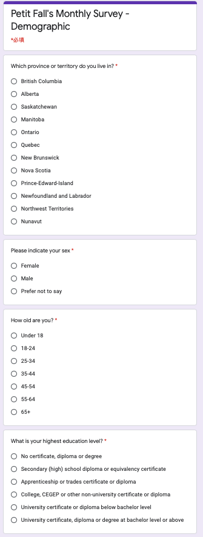

Survey_1

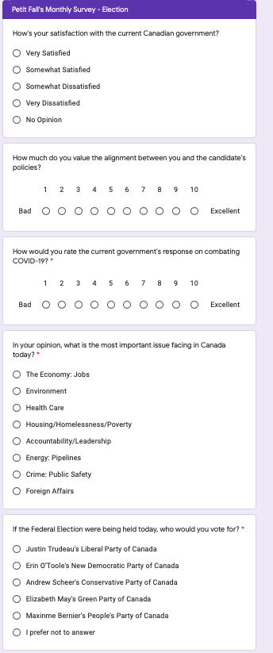

Survey2

# Reference

## Report Refernce

- H. Wickham. ggplot2: Elegant Graphics for Data Analysis. Springer-Verlag New York, 2016.
- R Core Team (2020). R: A language and environment for statistical computing. R Foundation for Statistical Computing, Vienna, Austria. URL https://www.R-project.org/.
- JJ Allaire and Yihui Xie and Jonathan McPherson and Javier Luraschi and Kevin Ushey and Aron Atkins and Hadley Wickham and Joe Cheng and Winston Chang and Richard Iannone (2020). rmarkdown: Dynamic Documents for R. R package version 2.3. URL https://rmarkdown.rstudio.com.
- Yihui Xie and J.J. Allaire and Garrett Grolemund (2018). R Markdown: The Definitive Guide. Chapman and Hall/CRC. ISBN
1. URL https://bookdown.org/yihui/rmarkdown.
- Hadley Wickham and Jennifer Bryan (2019). readxl: Read Excel Files. R package version 1.3.1. https://CRAN.R-project.org/package=readxl
- Hadley Wickham, Romain François, Lionel Henry and Kirill Müller (2020). dplyr: A Grammar of Data Manipulation. R package version 1.0.2. https://CRAN.R-project.org/package=dplyr
- Yihui Xie (2020). knitr: A General-Purpose Package for Dynamic Report Generation in R. R package version 1.29.
- Yihui Xie (2015) Dynamic Documents with R and knitr. 2nd edition. Chapman and Hall/CRC. ISBN 978-1498716963
- Yihui Xie (2014) knitr: A Comprehensive Tool for Reproducible Research in R. In Victoria Stodden, Friedrich Leisch and Roger D. Peng, editors, Implementing Reproducible Computational Research. Chapman and Hall/CRC. ISBN 978-1466561595
- Government of Canada, C. (2019, July 29). Communications Monitoring Report 2018. Retrieved October 08, 2020, from https://crtc.gc.ca/eng/publications/reports/policymonitoring/2018/cmr1.htm
- Canada Area Codes. (n.d.). Retrieved October 08, 2020, from https://www.allareacodes.com/canadian_area_codes.htm
- Wu, C., & Thompson, M. E. (2020). Sampling Theory and Practice. Cham: Springer International Publishing.
- Population of Canada by province and territory. (2020, October 06). Retrieved October 08, 2020, from https://en.wikipedia.org/wiki/Population_of_Canada_by_province_and_territory

## Data Simulation Reference

- CBC News Canada Poll Tracker. (n.d.). Retrieved October 08, 2020, from https://newsinteractives.cbc.ca/elections/poll-tracker/canada/
- Population of Canada by province and territory. (2020, October 06). Retrieved October 08, 2020, from https://en.wikipedia.org/wiki/Population_of_Canada_by_province_and_territory
- S. (2016). Data tables, 2016 Census. Retrieved October 08, 2020, from https://www12.statcan.gc.ca/census-recensement/2016/dp-pd/dt-td/Rp-eng.cfm?TABID=2
- S. (2016). Education Highlight Tables, 2016 Census. Retrieved October 08, 2020, from https://www12.statcan.gc.ca/census-recensement/2016/dp-pd/hlt-fst/edu-sco/Table.cfm?Lang=E